# Pathway Analysis w/ MSigDB

D. Ford Hannum

2025-06-10

```r
knitr::opts_chunk$set(echo = TRUE, message = FALSE)

# Set the directory to where everything is located
knitr::opts_knit$set(root.dir = '/Users/dfhannum/Desktop/OphthalmApp/') # sets it for all code chunks

library(Seurat) # for scRNA functions and plots
library(ggplot2) # for custom plotting
library(data.table) # data file processing and tstrsplit
library(clusterProfiler) # pathway analysis
library(org.Mm.eg.db) # <org.Hs.eg.db> human or <org.Rn.eg.db> rat
library(msigdbr) # access to MSigDB
```

# 1 Introduction

In this document we are going to use an already created Seurat scRNA object. We are then going to identify cluster markers, and submit those cluster markers for over-representation (enrichment) analysis with MSigDB. We will then make some plots representing the most significant pathways.

# 2 Data

I’m using a previously published dataset that I’ve reanalyzed for other example scripts.

```r
# Loading in the data
obj <- readRDS('./data/seurat_obj_full.Rds')
```

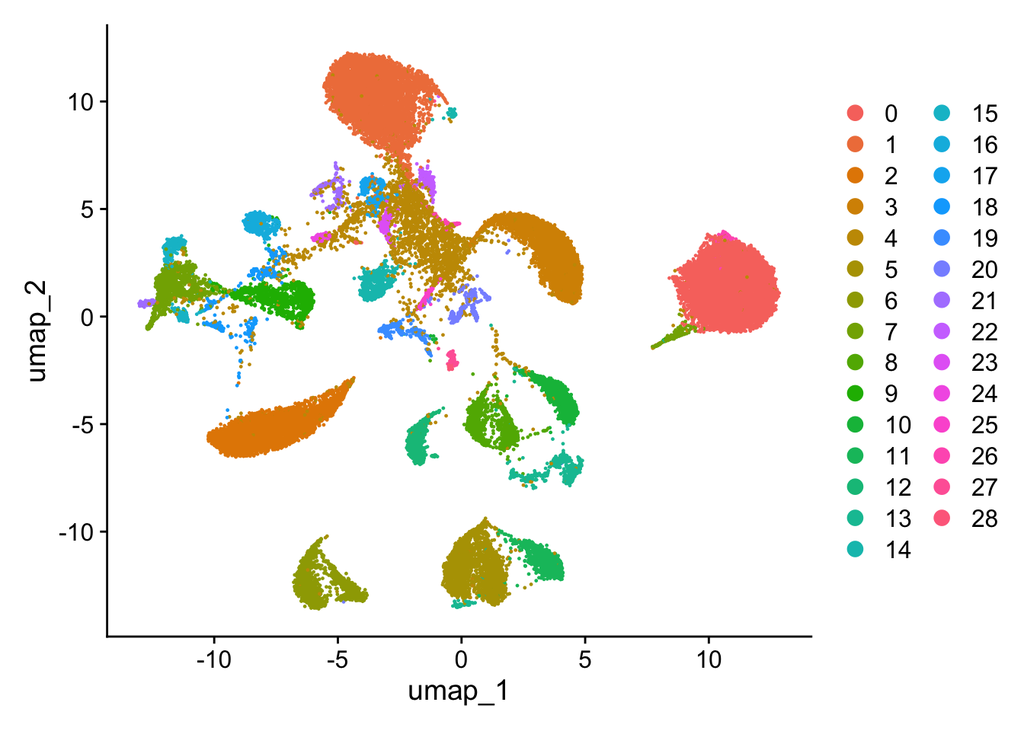

```r
# Visualizing the data
DimPlot(obj)
```

We are going to rerun the clustering to identify a smaller number of clusters. Many of these clusters will share similar transcriptomic profiles. For the speed/visualizations of my downstream example it’ll be easier working with fewer clusters.

```r
obj <- FindClusters(obj, resolution = .05)
```

```
## Modularity Optimizer version 1.3.0 by Ludo Waltman and Nees Jan van Eck
##
## Number of nodes: 36827
## Number of edges: 1171837
##
## Running Louvain algorithm...
## Maximum modularity in 10 random starts: 0.9915
## Number of communities: 14
## Elapsed time: 4 seconds
```

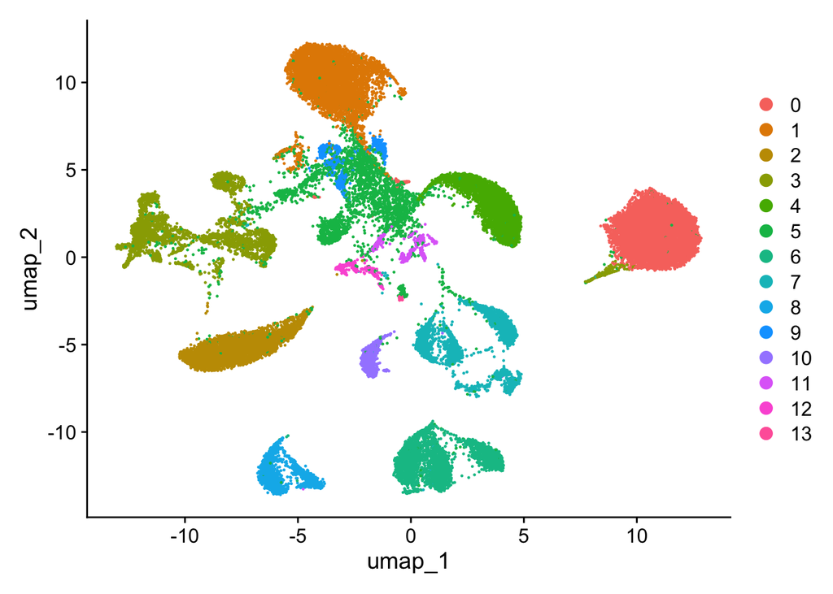

```r
# Projecting the data in umap space
DimPlot(obj)
```

# 3 Finding Cluster Marker Genes

```r
# Useful function to find markers for each cluster compared to all others
markers <- FindAllMarkers(object = obj,
                          only.pos = T, # focusing on upregulated markers
                          test.use = 'wilcox', # the default test that runs quickly
                          logfc.threshold = .2 # setting a strong cutoff
                          )
```

Next we are going to extract the differentially expressed genes for each cluster

```r
# Creating an empty list to add to
marker_list <- list()

# A for loop to loop through the clusters
# You can replace obj$seurat_clusters with your cluster identity
for (i in levels(obj$seurat_clusters)){

  # Print statements are always useful in for loops to track progress and to
  # make sure it's doing what it's suppose to
  print(paste0("Cluster ", i))

  # Isolating markers for the given cluster
  temp <- markers[markers$cluster == i,]

  # Only keeping significant markers
  temp <- temp[temp$p_val_adj < .05,]

  # Printing a statement saying how many markers we have
  print(paste0("Contains ", dim(temp)[1], ' markers'))

  # Adding the markers/gene to the list indexed by cluster
  marker_list[[i]] <- temp$gene
}
```

```
## [1] "Cluster 0"
## [1] "Contains 3240 markers"
## [1] "Cluster 1"
## [1] "Contains 5091 markers"
## [1] "Cluster 2"
## [1] "Contains 2368 markers"
## [1] "Cluster 3"
## [1] "Contains 5532 markers"
## [1] "Cluster 4"
## [1] "Contains 3057 markers"
## [1] "Cluster 5"
## [1] "Contains 1246 markers"
## [1] "Cluster 6"
## [1] "Contains 2237 markers"
## [1] "Cluster 7"
## [1] "Contains 2042 markers"
## [1] "Cluster 8"
## [1] "Contains 1580 markers"
## [1] "Cluster 9"
## [1] "Contains 4231 markers"
## [1] "Cluster 10"
## [1] "Contains 1875 markers"
## [1] "Cluster 11"
## [1] "Contains 2724 markers"
## [1] "Cluster 12"
## [1] "Contains 2712 markers"
## [1] "Cluster 13"
## [1] "Contains 2101 markers"
```

# 4 MSigDB

We will use the molecular signatures database ([MSigDB](https://www.gsea-msigdb.org/gsea/msigdb/)) to load their mouse collections to then run enrichment analysis with clusterProfiler

## 4.1 Database generation

In this chunk of code we will generate the database for use in clusterProfiler.

```r
# Loading all gene sets present in MSigDB for mouse
all_gene_sets <- msigdbr(species = 'Mus musculus')

head(all_gene_sets) # looking at the first six rows of the data
```

```
## # A tibble: 6 × 23
##   gene_symbol ncbi_gene ensembl_gene db_gene_symbol db_ncbi_gene db_ensembl_gene
##   <chr>       <chr>     <chr>        <chr>          <chr>        <chr>
## 1 Abcc4       239273    ENSMUSG0000… ABCC4          10257        ENSG00000125257
## 2 Abraxas2    109359    ENSMUSG0000… ABRAXAS2       23172        ENSG00000165660
## 3 Actn4       60595     ENSMUSG0000… ACTN4          81           ENSG00000130402
## 4 Acvr1       11477     ENSMUSG0000… ACVR1          90           ENSG00000115170
## 5 Adam9       11502     ENSMUSG0000… ADAM9          8754         ENSG00000168615
## 6 Adamts5     23794     ENSMUSG0000… ADAMTS5        11096        ENSG00000154736
## # ℹ 17 more variables: source_gene <chr>, gs_id <chr>, gs_name <chr>,
## #   gs_collection <chr>, gs_subcollection <chr>, gs_collection_name <chr>,
## #   gs_description <chr>, gs_source_species <chr>, gs_pmid <chr>,
## #   gs_geoid <chr>, gs_exact_source <chr>, gs_url <chr>, db_version <chr>,
## #   db_target_species <chr>, ortholog_taxon_id <int>, ortholog_sources <chr>,
## #   num_ortholog_sources <dbl>
```

Next we will look at the different collections in MSigDB.

```r
unique(all_gene_sets$gs_collection_name)[order(unique(all_gene_sets$gs_collection_name))]
```

```
##  [1] "BioCarta Pathways"
##  [2] "Cancer Gene Neighborhoods"
##  [3] "Cancer Modules"
##  [4] "Canonical Pathways"
##  [5] "Cell Type Signature"
##  [6] "Chemical and Genetic Perturbations"
##  [7] "Curated Cancer Cell Atlas gene sets "
##  [8] "GO Biological Process"
##  [9] "GO Cellular Component"
## [10] "GO Molecular Function"
## [11] "GTRD"
## [12] "Hallmark"
## [13] "HIPC Vaccine Response"
## [14] "Human Phenotype Ontology"
## [15] "ImmuneSigDB"
## [16] "KEGG Legacy Pathways"
## [17] "KEGG Medicus Pathways"
## [18] "MIR_Legacy"
## [19] "miRDB"
## [20] "Oncogenic Signature"
## [21] "PID Pathways"
## [22] "Positional"
## [23] "Reactome Pathways"
## [24] "TFT_Legacy"
## [25] "WikiPathways"
```

More details about the collections are available.

```r
head(msigdbr_collections())
```

```
## # A tibble: 6 × 4
##   gs_collection gs_subcollection  gs_collection_name                num_genesets
##   <chr>         <chr>             <chr>                                    <int>
## 1 C1            ""                Positional                                 302
## 2 C2            "CGP"             Chemical and Genetic Perturbatio…         3494
## 3 C2            "CP"              Canonical Pathways                          19
## 4 C2            "CP:BIOCARTA"     BioCarta Pathways                          292
## 5 C2            "CP:KEGG_LEGACY"  KEGG Legacy Pathways                       186
## 6 C2            "CP:KEGG_MEDICUS" KEGG Medicus Pathways                      658
```

```r
# Collecting unique rows in the database and creating the term to gene object
msigdbr_t2g <- dplyr::distinct(all_gene_sets, gs_name, gene_symbol)
```

## 4.2 Running enricher

Next we will run the enricher function on the top markers from each cluster.

```r
pathway_results <- list()
for (i in names(marker_list)){
  print(i)

  res <- enricher(gene = marker_list[[i]], # cluster marker genes
                  TERM2GENE = msigdbr_t2g, # reference database
                  pvalueCutoff = 1)

  pathway_results[[i]] <- res
}
```

```
## [1] "0"
## [1] "1"
## [1] "2"
## [1] "3"
## [1] "4"
## [1] "5"
## [1] "6"
## [1] "7"
## [1] "8"
## [1] "9"
## [1] "10"
## [1] "11"
## [1] "12"
## [1] "13"
```

```r
temp <- pathway_results[[1]]

temp
```

```
## #
## # over-representation test
## #
## #...@organism     UNKNOWN
## #...@ontology     UNKNOWN
## #...@gene     chr [1:3240] "Slc24a1" "Cnga1" "Nr2e3" "Cngb1" "Impg1" "Pde6a" "Samd11" ...
## #...pvalues adjusted by 'BH' with cutoff <1
## #...4674 enriched terms found
## 'data.frame':    4674 obs. of  12 variables:
##  $ ID            : chr  "CRX_NRL_DN.V1_UP" "CRX_DN.V1_UP" "NRL_DN.V1_UP" "HP_NYCTALOPIA" ...
##  $ Description   : chr  "CRX_NRL_DN.V1_UP" "CRX_DN.V1_UP" "NRL_DN.V1_UP" "HP_NYCTALOPIA" ...
##  $ GeneRatio     : chr  "109/2824" "98/2824" "95/2824" "105/2824" ...
##  $ BgRatio       : chr  "137/17963" "132/17963" "136/17963" "218/17963" ...
##  $ RichFactor    : num  0.796 0.742 0.699 0.482 0.471 ...
##  $ FoldEnrichment: num  5.06 4.72 4.44 3.06 3 ...
##  $ zScore        : num  20.6 18.5 17.4 13.2 12.4 ...
##  $ pvalue        : num  5.15e-62 6.54e-51 1.53e-45 1.46e-29 1.92e-26 ...
##  $ p.adjust      : num  1.35e-57 8.61e-47 1.34e-41 9.62e-26 1.01e-22 ...
##  $ qvalue        : num  1.16e-57 7.36e-47 1.15e-41 8.23e-26 8.66e-23 ...
##  $ geneID        : chr  "Slc24a1/Cnga1/Nr2e3/Cngb1/Impg1/Pde6a/Samd11/Nrl/Reep6/Esrrb/Rdh12/Rtbdn/Pla2r1/Nxnl2/Kcnj14/Dpf3/Grtp1/Faim/Gu"| __truncated__ "Slc24a1/Cngb1/Pde6a/Reep6/Vtn/Esrrb/Rdh12/Rtbdn/Grk1/Abca4/Pla2r1/Nxnl2/Kcnj14/Dpf3/Grtp1/Faim/Guca1b/Pfkfb2/Cd"| __truncated__ "Slc24a1/Cnga1/…
##  $ Count         : int  109 98 95 105 97 164 64 59 105 86 ...
## #...Citation
##  T Wu, E Hu, S Xu, M Chen, P Guo, Z Dai, T Feng, L Zhou, W Tang, L Zhan, X Fu, S Liu, X Bo, and G Yu.
##  clusterProfiler 4.0: A universal enrichment tool for interpreting omics data.
##  The Innovation. 2021, 2(3):100141
```

```r
# Put it in dataframe form to query and plot
temp <- as.data.frame(temp)

dim(temp)
```

```
## [1] 4674   12
```

```r
head(temp)
```

```
##                                                          ID
## CRX_NRL_DN.V1_UP                           CRX_NRL_DN.V1_UP
## CRX_DN.V1_UP                                   CRX_DN.V1_UP
## NRL_DN.V1_UP                                   NRL_DN.V1_UP
## HP_NYCTALOPIA                                 HP_NYCTALOPIA
## HP_ABNORMAL_ELECTRORETINOGRAM HP_ABNORMAL_ELECTRORETINOGRAM
## GOBP_MRNA_PROCESSING                   GOBP_MRNA_PROCESSING
##                                                 Description GeneRatio   BgRatio
## CRX_NRL_DN.V1_UP                           CRX_NRL_DN.V1_UP  109/2824 137/17963
## CRX_DN.V1_UP                                   CRX_DN.V1_UP   98/2824 132/17963
## NRL_DN.V1_UP                                   NRL_DN.V1_UP   95/2824 136/17963
## HP_NYCTALOPIA                                 HP_NYCTALOPIA  105/2824 218/17963
## HP_ABNORMAL_ELECTRORETINOGRAM HP_ABNORMAL_ELECTRORETINOGRAM   97/2824 206/17963
## GOBP_MRNA_PROCESSING                   GOBP_MRNA_PROCESSING  164/2824 469/17963
##                               RichFactor FoldEnrichment   zScore       pvalue
## CRX_NRL_DN.V1_UP               0.7956204       5.060811 20.60664 5.148974e-62
## CRX_DN.V1_UP                   0.7424242       4.722439 18.53906 6.541578e-51
## NRL_DN.V1_UP                   0.6985294       4.443231 17.40835 1.530170e-45
## HP_NYCTALOPIA                  0.4816514       3.063705 13.24034 1.462337e-29
## HP_ABNORMAL_ELECTRORETINOGRAM  0.4708738       2.995151 12.43900 1.923784e-26
## GOBP_MRNA_PROCESSING           0.3496802       2.224258 11.60315 2.534509e-25
##                                   p.adjust       qvalue
## CRX_NRL_DN.V1_UP              1.354747e-57 1.158465e-57
## CRX_DN.V1_UP                  8.605773e-47 7.358931e-47
## NRL_DN.V1_UP                  1.342010e-41 1.147574e-41
## HP_NYCTALOPIA                 9.618888e-26 8.225262e-26
## HP_ABNORMAL_ELECTRORETINOGRAM 1.012334e-22 8.656624e-23
## GOBP_MRNA_PROCESSING          1.034829e-21 8.848982e-22
##                                                                                                                                                                                                                                                                                                          …
## CRX_NRL_DN.V1_UP                                                                                                                                                                                                                                                                                         …
## CRX_DN.V1_UP                                                                                                                                                                                                                                                                                             …
## NRL_DN.V1_UP                                                                                                                                                                                                                                                                                             …
## HP_NYCTALOPIA                                                                                                                                                                                                                                                                                            …
## HP_ABNORMAL_ELECTRORETINOGRAM                                                                                                                                                                                                                                                                            …
## GOBP_MRNA_PROCESSING          Mbnl1/Ahcyl1/Pcbp4/Hnrnpu/Rsrp1/Ddx5/Mbnl2/Thoc5/Ssu72/Ybx1/…
##                               Count
## CRX_NRL_DN.V1_UP                109
## CRX_DN.V1_UP                     98
## NRL_DN.V1_UP                     95
## HP_NYCTALOPIA                   105
## HP_ABNORMAL_ELECTRORETINOGRAM    97
## GOBP_MRNA_PROCESSING            164
```

Here we have the gene set name but not the collection they belong to, so we’ll need to map back to that.

```r
# creating a dataframe with gene sets mapped to their collection name
collections <- as.data.frame(dplyr::distinct(all_gene_sets, gs_name, gs_collection_name))

# # Checking that they all overlap
# table(temp$ID %in% collections$gs_name)

rownames(collections) <- collections$gs_name
temp$collection <- collections[temp$ID,]$gs_collection_name

# Looking at how many entries we have for each collection in our results
table(temp$collection)
```

```
##
##                    BioCarta Pathways            Cancer Gene Neighborhoods
##                                   19                                  116
##                       Cancer Modules                   Canonical Pathways
##                                   44                                    1
##                  Cell Type Signature   Chemical and Genetic Perturbations
##                                   24                                  215
## Curated Cancer Cell Atlas gene sets                 GO Biological Process
##                                    4                                  475
##                GO Cellular Component                GO Molecular Function
##                                  134                                  180
##                                 GTRD                             Hallmark
##                                  123                                    6
##                HIPC Vaccine Response             Human Phenotype Ontology
##                                   28                                  685
##                          ImmuneSigDB                 KEGG Legacy Pathways
##                                 1181                                   11
##                KEGG Medicus Pathways                           MIR_Legacy
##                                   27                                  128
##                                miRDB                  Oncogenic Signature
##                                  866                                   20
##                         PID Pathways                           Positional
##                                   20                                   18
##                    Reactome Pathways                           TFT_Legacy
##                                  187                                  108
##                         WikiPathways
##                                   54
```

```r
# Looking at the number of significant entries (TRUE) for each collection
table(temp$collection,temp$p.adjust < .05)
```

```
##
##                                        FALSE TRUE
##   BioCarta Pathways                       15    4
##   Cancer Gene Neighborhoods               52   64
##   Cancer Modules                          30   14
##   Canonical Pathways                       1    0
##   Cell Type Signature                     11   13
##   Chemical and Genetic Perturbations     115  100
##   Curated Cancer Cell Atlas gene sets      0    4
##   GO Biological Process                  244  231
##   GO Cellular Component                   54   80
##   GO Molecular Function                   86   94
##   GTRD                                    43   80
##   Hallmark                                 2    4
##   HIPC Vaccine Response                    7   21
##   Human Phenotype Ontology               364  321
##   ImmuneSigDB                            564  617
##   KEGG Legacy Pathways                     5    6
##   KEGG Medicus Pathways                   21    6
##   MIR_Legacy                              48   80
##   miRDB                                  440  426
##   Oncogenic Signature                     10   10
##   PID Pathways                             9   11
##   Positional                              14    4
##   Reactome Pathways                       87  100
##   TFT_Legacy                              58   50
##   WikiPathways                            32   22
```

### 4.3.1 WikiPathways Results

Next we’ll view and plot the WikiPathways results, one of the collections in MSigDB.

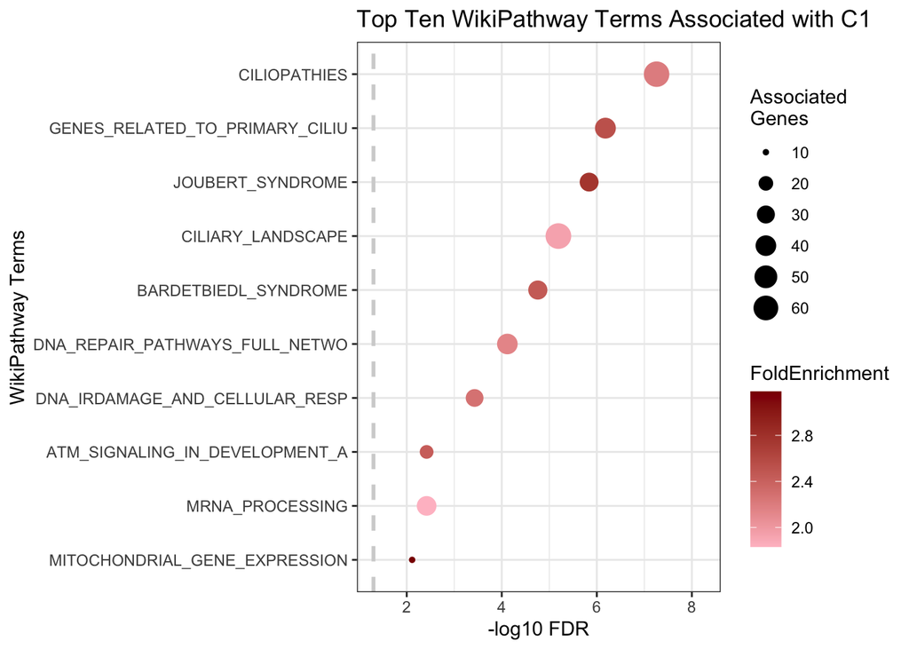

```r
wiki <- temp[temp$collection == 'WikiPathways',] # subsetting to just Wiki results

wiki$id <- gsub('WP_','', wiki$ID) # removing the WP_ preceder from term IDs
wiki$id <- substr(wiki$id,1,30) # limiting to thirty characters for ID bc some get long
wiki$id <- factor(wiki$id, levels = rev(unique(wiki$id))) # ordering them by p-vals

ggplot(wiki[1:10,], # only plotting the first ten
       aes(x = -log10(p.adjust),
           y = id,
           color = FoldEnrichment,
           size = Count)) +
  theme_bw() + # my theme of choice
  geom_point() +
  scale_color_gradient(low = 'pink', high = 'darkred') + # creating a monotonic color scheme
  # creating a significance cutoff to let viewers know all values plotted are significant
  geom_vline(xintercept = -log10(0.05), colour = 'lightgrey', linetype = 2, linewidth = 1) +
  # increasing the xlims because the larger points were getting cut off
  xlim(c(-log10(0.05),-log10(min(wiki$p.adjust)) + 1)) +
  # cleaning up the labels on the graph
  labs(fill = 'Fold\nEnrichment',
       size = 'Associated\nGenes') +
  xlab('-log10 FDR') +
  ylab("WikiPathway Terms") +
  ggtitle("Top Ten WikiPathway Terms Associated with C1")
```